# RestREco

# Alpha diversity

**Alpha diversity** describes the richness and/or evenness of microbial community within a single sample.

## Plots

There are many measures of **Alpha diversity**. Here we plot *Shannon* and *Simpson* indices only.

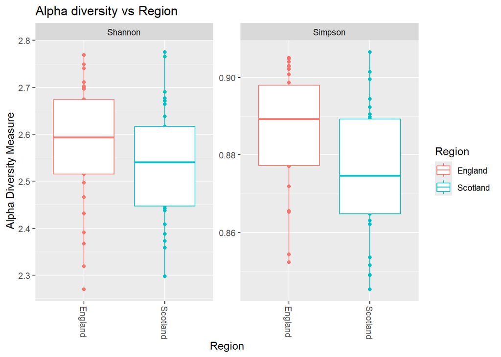

```r
plot_richness(BacIndAgriClassAbundNorm.phy,
              measures=c("Shannon", "Simpson"),
              color="Region", x="Region",
              title="Alpha diversity vs Region") +
  geom_boxplot()
```

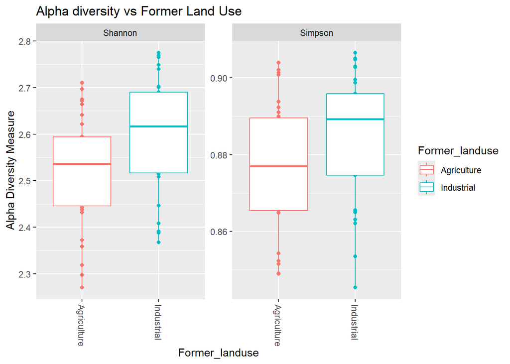

```r
plot_richness(BacIndAgriClassAbundNorm.phy,
              measures=c("Shannon", "Simpson"),
              color="Former_landuse", x="Former_landuse",
              title="Alpha diversity vs Former Land Use") +
  geom_boxplot()
```

## Estimating statistical significance

Here we will explore different statistical models to estimate what factors may affect the Shannon diversity. Visual assessment of the plots suggests that alpha diversity may depend on the former land use and region.

In general, the statistical modelling should account for study design and for sparsity/compositionality of the data.

The design may include mixed model, nesting and croissing the factors.

Because of the **compositionality** (relative nature) and high **sparsity** of the standard statistical tests assuming normality of distributions usually are not appropriate for microbial data. Instead, it is recommended to use **non-parametric** tests (or specialized and **permutation-based** tests).

### Prepare data

```r
# Calculate Alpha diversity indices
alpha_richness.df = estimate_richness(
  BacIndAgriClassAbundNorm.phy, measures = c("Shannon", "Simpson"))

head(alpha_richness.df)
```

```
##       Shannon   Simpson
## EW01 2.431518 0.8654150
## EW02 2.318614 0.8542854
## EW03 2.621795 0.8937610
## EW04 2.496689 0.8770398
## EW05 2.696819 0.9021534
## EW06 2.537609 0.8798479
```

```r
# Extract metadata from phyloseq object
data.df <- data.frame(sample_data(BacIndAgriClassAbundNorm.phy))

# Explore and reformat data
data.df <- data.df %>%
  select(Region,
         Use=Former_landuse,
         Site=Site_code,
         Age=Woodland_age,
         pH, Conductivity)

str(data.df)
```

```
## 'data.frame':    59 obs. of  6 variables:
##  $ Region      : Factor w/ 2 levels "England","Scotland": 1 1 1 1 1 1 1 1 1 1 ...
##  $ Use         : Factor w/ 2 levels "Agriculture",..: 1 1 1 1 1 1 1 1 1 1 ...
##  $ Site        : Factor w/ 59 levels "EW01","EW02",..: 1 2 3 4 5 6 7 8 9 10 ...
##  $ Age         : int  14 17 13 27 22 23 30 27 39 47 ...
##  $ pH          : num  4.86 4.7 7.87 5.01 7.91 5.25 5.33 6.03 5.92 5.58 ...
##  $ Conductivity: num  88.2 64 158 75 145 ...
```

```r
# Add Shannon diversity
all(rownames(data.df) == rownames(alpha_richness.df))
```

```
## [1] TRUE
```

```r
data.df <- data.frame(Shannon=alpha_richness.df$Shannon, data.df)

# Explore result
str(data.df)
```

```
## 'data.frame':    59 obs. of  7 variables:
##  $ Shannon     : num  2.43 2.32 2.62 2.5 2.7 ...
##  $ Region      : Factor w/ 2 levels "England","Scotland": 1 1 1 1 1 1 1 1 1 1 ...
##  $ Use         : Factor w/ 2 levels "Agriculture",..: 1 1 1 1 1 1 1 1 1 1 ...
##  $ Site        : Factor w/ 59 levels "EW01","EW02",..: 1 2 3 4 5 6 7 8 9 10 ...
##  $ Age         : int  14 17 13 27 22 23 30 27 39 47 ...
##  $ pH          : num  4.86 4.7 7.87 5.01 7.91 5.25 5.33 6.03 5.92 5.58 ...
##  $ Conductivity: num  88.2 64 158 75 145 ...
```

```r
head(data.df)
```

```
##       Shannon  Region         Use Site Age   pH Conductivity
## EW01 2.431518 England Agriculture EW01  14 4.86         88.2
## EW02 2.318614 England Agriculture EW02  17 4.70         64.0
## EW03 2.621795 England Agriculture EW03  13 7.87        158.0
## EW04 2.496689 England Agriculture EW04  27 5.01         75.0
## EW05 2.696819 England Agriculture EW05  22 7.91        145.0
## EW06 2.537609 England Agriculture EW06  23 5.25         93.0
```

```r
# Clean-up
rm(alpha_richness.df)
```

### Wilcoxon test

Significant for Prior Land Use (p=0.02)

```r
wilcox.test(Shannon~Region, data=data.df)
```

```
##
##  Wilcoxon rank sum exact test
##
## data:  Shannon by Region
## W = 522, p-value = 0.1912
## alternative hypothesis: true location shift is not equal to 0
```

```r
wilcox.test(Shannon~Use, data=data.df)
```

```
##
##  Wilcoxon rank sum exact test
##
## data:  Shannon by Use
## W = 287, p-value = 0.02455
## alternative hypothesis: true location shift is not equal to 0
```

### Regression model

Trend for significance for Prior Land Use in Scotland (p=0.07)

```r
fit <- lm(Shannon~Region/Use, data=data.df)
summary(fit)
```

```
##
## Call:
## lm(formula = Shannon ~ Region/Use, data = data.df)
##
## Residuals:
##       Min        1Q    Median        3Q       Max
## -0.271183 -0.068476  0.007665  0.086165  0.194744
##
## Coefficients:
##                              Estimate Std. Error t value Pr(>|t|)
## (Intercept)                   2.54133    0.03118  81.496   <2e-16 ***
## RegionScotland               -0.04399    0.04410  -0.997   0.3229
## RegionEngland:UseIndustrial   0.06745    0.04410   1.530   0.1319
## RegionScotland:UseIndustrial  0.08297    0.04488   1.849   0.0699 .
## ---
## Signif. codes:  0 '***' 0.001 '**' 0.01 '*' 0.05 '.' 0.1 ' ' 1
##
## Residual standard error: 0.1208 on 55 degrees of freedom
## Multiple R-squared:  0.1156, Adjusted R-squared:  0.06739
## F-statistic: 2.397 on 3 and 55 DF,  p-value: 0.07791
```

```r
rm(fit)
```

# Beta diversity

Beta diversity is often illustrated by plots showing unconstrained ordination of samples.

Term “**ordination**” in ecology is used for **dimentionality reduction** and visualization techniques (similar to PCA). The idea is to make a 2D (or 3D) image that would reflect similarity/distances between samples (or taxa). The plot should show similar samples (or taxa) close to each other, while the dissimilar samples (or taxa) should be drown far apart.

## Plotting

### Calculating unconstrained ordination

Technically, an (*unconstrained*) ordination procedure includes two main steps:

- calculating distances between samples, and
- making a plot to reflect these distances in 2D image in a best possible way.

In the example below we use **Bray-Curtis** distance and **PCoA** method for making the plot. See help to the **ordinate()** function (**?ordinate**) to find information about other available distances and methods.

Here we consider the *unconstrained* ordination only. The *constrained* ordination includes additional steps, which allow adding some environmental gradients (e.g. soil pH) to the plot: so we can see how the samples & taxa are positioned along these gradients.

```r
ord <- ordinate(BacIndAgriClassAbundNorm.phy,
                distance = "bray",
                method = "PCoA")
```

### Plotting with Phyloseq

**Beta diversity**, in effect, is an unconstrained ordination of **samples**. The samples located closely on the plot have similar microbial communities, the samples located far apart have very distinct microbial communities.

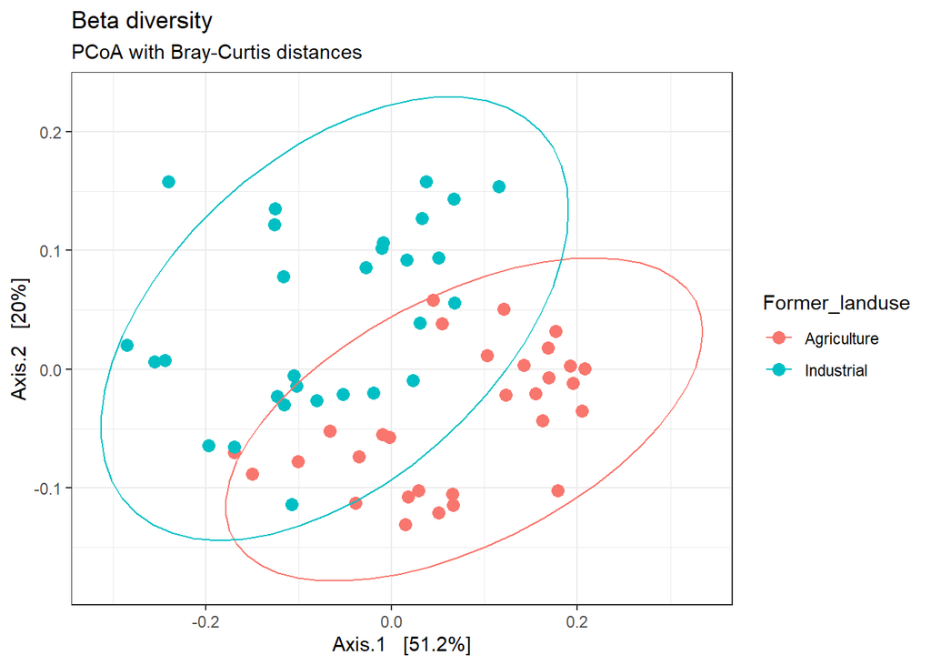

```r
plot_ordination(BacIndAgriClassAbundNorm.phy, ord, type="samples",
                color="Former_landuse") + geom_point(size=3) +
  stat_ellipse() +
  ggtitle("Beta diversity",
          subtitle="PCoA with Bray-Curtis distances")+
  theme_bw()
```

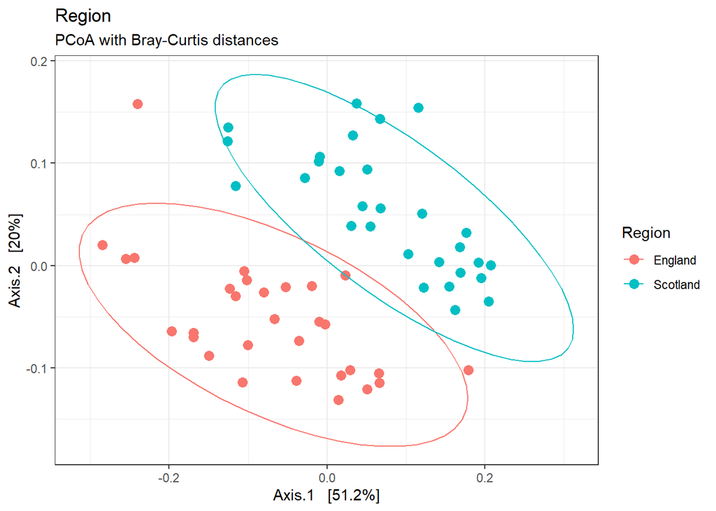

```r
plot_ordination(BacIndAgriClassAbundNorm.phy, ord, type="samples",
                color="Region") + geom_point(size=3) +
  stat_ellipse() +
  ggtitle("Region",
          subtitle="PCoA with Bray-Curtis distances")+
  theme_bw()
```

```r
# Clean-up
rm(ord)
```

## Evaluating statisitcal significance

### Calculate distance matrix with Phyloseq

```r
bray.dist <- distance(BacIndAgriClassAbundNorm.phy, method="bray")
as.matrix(bray.dist)[1:5,1:5]
```

```
##           EW01      EW02       EW03      EW04       EW05
## EW01 0.0000000 0.1284722 0.29026658 0.1679484 0.31201190
## EW02 0.1284722 0.0000000 0.34969629 0.1624504 0.37414797
## EW03 0.2902666 0.3496963 0.00000000 0.1923125 0.05700124
## EW04 0.1679484 0.1624504 0.19231246 0.0000000 0.21631338
## EW05 0.3120119 0.3741480 0.05700124 0.2163134 0.00000000
```

### PERMANOVA with Vegan::Adonis2

Judging by the **Beta diversity** plots the soil communities are quite different depending on the region or prior use.

As it was noted earlier, the microbial data requires specialized tests. The most commonly used test for estimating **Beta diversity** statistical significance is **PERMANOVA** (PERmutation based Multivariate ANOVA) implemented in **adonis2()** function from the **vegan** package.

Note formula within the **vegan::adonis2()** function:  
**~Region/Use**.  
This is a way of describing nested designs in R.

Also, note the **strata=Region** term: it does not allow permutations between regions (?)

Effects of possible covariates, such as age, pH and conductivity are not yet explored.

```r
library(vegan)

# Using fixed effects nested model
adonis2(bray.dist ~ Region/Use,
        strata = data.df$Region,
        data = data.df, permutations=1000)
```

```
## Permutation test for adonis under reduced model
## Terms added sequentially (first to last)
## Blocks:  strata
## Permutation: free
## Number of permutations: 1000
##
## adonis2(formula = bray.dist ~ Region/Use, data = data.df, permutations = 1000, strata = data.df$Region)
##            Df SumOfSqs      R2      F   Pr(>F)
## Region      1  0.50407 0.27072 31.016 0.000999 ***
## Region:Use  2  0.46403 0.24922 14.276 0.000999 ***
## Residual   55  0.89386 0.48006
## Total      58  1.86196 1.00000
## ---
## Signif. codes:  0 '***' 0.001 '**' 0.01 '*' 0.05 '.' 0.1 ' ' 1
```

```r
# Clean-up
rm(data.df, bray.dist)
```

# Visualising taxonoimy

**ToDo:** Update colours!

Visualizing taxonomy is an important part of exploring microbial data.

**Phyloseq** provides **plot_bar()** function that outputs a **ggplot** object that can be directly piped to the **geom_bar()** layer.

## Combining samples

**Phyloseq** function **merge_samples()** allows to combine samples, so we can compare groups of samples. In this example we will combine soil samples by the Prior Land Use.

Important: after merging samples, the data should be re-normalised!

```r
# Merge samples in groups (warnings are OK)
landUse.phy <- merge_samples(BacIndAgriClassAbundNorm.phy, "Former_landuse")
landUse.phy
```

```
## phyloseq-class experiment-level object
## otu_table()   OTU Table:         [ 78 taxa and 2 samples ]
## sample_data() Sample Data:       [ 2 samples by 7 sample variables ]
## tax_table()   Taxonomy Table:    [ 78 taxa by 7 taxonomic ranks ]
## phy_tree()    Phylogenetic Tree: [ 78 tips and 77 internal nodes ]
```

```r
# Re-Normalize after merging samples !
landUse.phy  = transform_sample_counts(landUse.phy, function(x) x / sum(x))
```

## Combining low-abundant taxa

Combining low-abundant taxa may make the taxa bar-plot clearer.

Unfortunately, **plot_bar()** does not provide such option. The code below illustrates how it can be done (modified from the Phyloseq author post https://github.com/joey711/phyloseq/issues/494 ).

It includes 3 steps:

- Converting **Phyloseq** object **to a large data frame** using **psmelt()** function
- Substituting rare phyla to “others” (e.g. Phyla with count <1%)
- Using the updated data frame for the ggplot stacked barplot

```r
# Convert Phyloseq object to large data frame
MeltData.df <- psmelt(landUse.phy)
MeltData.df[1:5,1:12]
```

```
##                                  OTU      Sample Abundance Site_code Site_name   Region Former_landuse Woodland_age       pH Conductivity     Kingdom           Phylum
## 151 f898c7a8c566d0beb46d5448dde2387c Agriculture 0.2500062  23.00000  29.70000 1.500000              1     36.83333 5.478333     79.27667 d__Bacteria   Proteobacteria
## 152 f898c7a8c566d0beb46d5448dde2387c  Industrial 0.2227048  37.24138  30.31034 1.482759              2     38.96552 6.038276     95.29345 d__Bacteria   Proteobacteria
## 70  5fc1ccf16272b9a800d1da9415d1d86b  Industrial 0.1223218  37.24138  30.31034 1.482759              2     38.96552 6.038276     95.29345 d__Bacteria   Proteobacteria
## 153 f97cd7302801793ec81407f5010a0211  Industrial 0.1095570  37.24138  30.31034 1.482759              2     38.96552 6.038276     95.29345 d__Bacteria Actinobacteriota
## 121 bee7f66cb24e2cdbeb380b0cc15fd66d Agriculture 0.1062696  23.00000  29.70000 1.500000              1     36.83333 5.478333     79.27667 d__Bacteria     Firmicutes_D
```

```r
# Get counts per phylum
Phyla.df <- MeltData.df %>%
  group_by(Phylum) %>%
  summarise(Count=sum(Abundance))

Phyla.df
```

```
## # A tibble: 38 × 2
##    Phylum                Count
##    <chr>                 <dbl>
##  1 Acidobacteriota    0.323
##  2 Actinobacteriota   0.371
##  3 Armatimonadota     0.000474
##  4 Bacteroidota       0.0545
##  5 Bdellovibrionota_E 0.00293
##  6 Chlamydiota        0.00117
##  7 Chloroflexota      0.0597
##  8 Cyanobacteria      0.000311
##  9 Dependentiae       0.000505
## 10 Desulfobacterota_B 0.0281
## # ℹ 28 more rows
```

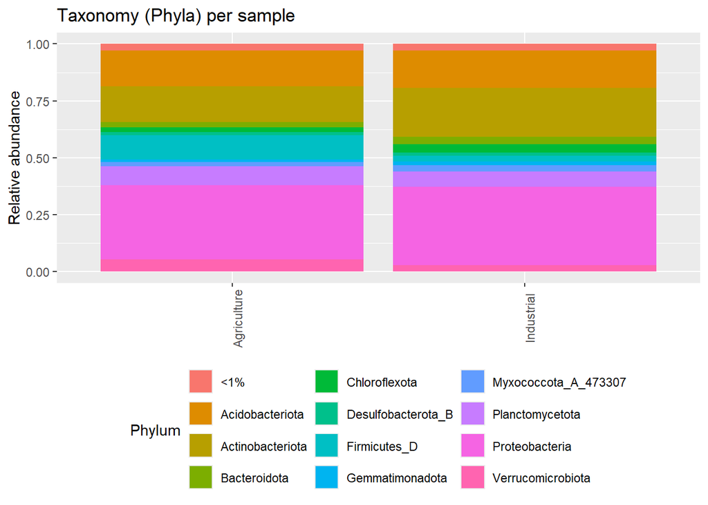

```r
# Select the cut-off (e.g. 1% of total count)
cutoff <- 0.01 * sum(MeltData.df$Abundance)

# Select low-abundant Phyla (with total counts below the cutoff)
lowAbundant <- Phyla.df[Phyla.df$Count <= cutoff,]$Phylum

# Substitute Phylum names to "<1%" for the low-abundant phyla
MeltData.df[MeltData.df$Phylum %in% lowAbundant,]$Phylum <- '<1%'

# Make stacked barplot
ggplot(MeltData.df, aes(x=Sample, y=Abundance, fill=Phylum)) +
  geom_bar(aes(), stat="identity", position="stack") +
  theme(legend.position="bottom") +
  ggtitle("Taxonomy (Phyla) per sample") +
  guides(fill=guide_legend(nrow=3)) +
  theme(axis.text.x = element_text(angle = 90)) +
  labs(y= "Relative abundance", x = NULL) +
  theme(legend.position = "bottom") +
  guides(fill=guide_legend(ncol=3))
```

```r
# Clean-up
rm(landUse.phy, MeltData.df, Phyla.df, cutoff, lowAbundant)
```

# Differential abundance with ancombc2

**ANCOMBC** package implements a method for **differential abundance analysis**, which takes into account the compositionality of microbial data: https://www.nature.com/articles/s41467-020-17041-7

Like **Vegan** and **Phyloseq**, **ANCOMBC** is a very popular package, and it can directly accept the **Phyloseq** objects.

```r
detach("package:phyloseq", unload=TRUE) # unload phyloseq package (to avoid warnings from ANCOMBC)

# Lad package
library(ANCOMBC)

# Estimate differential abundances
# ~5min, multiple warnings are OK
ancom.output = ancombc2(data = BacIndAgriClassAbundNorm.phy, tax_level = "Class",
                fix_formula = "Former_landuse",
                group = "Former_landuse",
                p_adj_method = "holm", alpha = 0.05, pairwise = TRUE,
                prv_cut = 0.10, lib_cut = 1000,
                n_cl = 4, verbose = TRUE)

# Clean-up
detach("package:ANCOMBC", unload=TRUE) # unload ANCOMBC package (just in case)
```

## Extract results from ancombc2 output

The **ancombc2** output contains many components that we don’t need for the downstream analysis. We only need the **table with results**. Moreover, within this table we will only use selected **columns describing Former Landuse** (ignoring the data about intercept).

The columns that we need are:

- **taxon**: the taxa (at Class level in our case)
- **lfc_Former_landuseIndustrial**: Log Fold Change (Industrial vs Agriculture)
- **se_Former_landuseIndustrial**: Standard error for LFC
- **W_Former_landuseIndustrial**: The statistics calculated by ANCOMBC
- **p_Former_landuseIndustrial**: p-value for the statistics (w/o the multiple testing correction)
- **q_Former_landuseIndustrial**: significance after the multiple testing correction
- **diff_Former_landuseIndustrial**: Is this taxon differentially abundant ? (TRUE/FALSE)
- **passed_ss_Former_landuseIndustrial**: Has the taxon passed the additional ANCOMBC check? (TRUE/FALSE)

```r
# Extract the results table
results.df <- ancom.output$res
colnames(results.df)
```

```
##  [1] "taxon"                              "lfc_(Intercept)"                    "lfc_Former_landuseIndustrial"       "se_(Intercept)"                     "se_Former_landuseIndustrial"        "W_(Intercept)"                      "W_Former_landuseIndustrial"         "p_(Intercept)"                  …
```

```r
dim(results.df) # Taxa at Class level
```

```
## [1] 72 15
```

```r
# Select only columns that we need
all_results.df <- results.df %>%
  select(taxon, contains("Former_landuse"))
colnames(all_results.df)
```

```
## [1] "taxon"                              "lfc_Former_landuseIndustrial"       "se_Former_landuseIndustrial"        "W_Former_landuseIndustrial"         "p_Former_landuseIndustrial"         "q_Former_landuseIndustrial"         "diff_Former_landuseIndustrial"      "passed_ss_Former_landuseIndustria…
```

```r
dim(all_results.df)
```

```
## [1] 72  8
```

```r
head(all_results.df)
```

[output not shown]

```r
# Clean-up
rm(results.df, ancom.output)
```